# PCA_WGNCA

### Log-transform the count data

First we are going to log-transform the data using a variance stabilizing transforamtion (VST). This is only for visualization purposes. Essentially, this is roughly similar to putting the data on the log2 scale. It will deal with the sampling variability of low counts by calculating within-group variability (if blind=FALSE). Importantly, it does not use the design to remove variation in the data, and so can be used to examine if there may be any variability do to technical factors such as extraction batch effects.

To do this we first need to calculate the size factors of our samples. This is a rough estimate of how many reads each sample contains compared to the others. In order to use VST (the faster log2 transforming process) to log-transform our data, the size factors need to be less than 4. Otherwise, there could be artefacts in our results.

```r
SF.gdds <- estimateSizeFactors(gdds) #estimate size factors to determine if we can use vst  to transform our data. Size factors should be less than 4 for us to use vst
print(sizeFactors(SF.gdds)) #View size factors
```

```
## clean.A10.KW10_S233_ALL.fastq.gz_quant clean.A11.KW11_S236_ALL.fastq.gz_quant
##                             3.06346957                             2.68415912
## clean.A12.KW12_S239_ALL.fastq.gz_quant   clean.A1.KW1_S197_ALL.fastq.gz_quant
##                             1.97679854                             2.50366957
##   clean.A2.KW2_S201_ALL.fastq.gz_quant   clean.A3.KW3_S205_ALL.fastq.gz_quant
##                             2.02592848                             1.29477342
##   clean.A4.KW4_S209_ALL.fastq.gz_quant   clean.A5.KW5_S213_ALL.fastq.gz_quant
##                             3.24168851                             2.27191757
##   clean.A6.KW6_S217_ALL.fastq.gz_quant   clean.A7.KW7_S221_ALL.fastq.gz_quant
##                             2.83135718                             0.85033631
##   clean.A8.KW8_S225_ALL.fastq.gz_quant   clean.A9.KW9_S229_ALL.fastq.gz_quant
##                             0.42246842                             0.84044803
## clean.B10.KW22_S234_ALL.fastq.gz_quant clean.B11.KW23_S237_ALL.fastq.gz_quant
##                             0.52487186                             0.56597295
## clean.B12.KW24_S240_ALL.fastq.gz_quant  clean.B1.KW13_S198_ALL.fastq.gz_quant
##                             0.39228281                             1.64435852
##  clean.B2.KW14_S202_ALL.fastq.gz_quant  clean.B3.KW15_S206_ALL.fastq.gz_quant
##                             0.26746317                             0.25670331
##  clean.B4.KW16_S210_ALL.fastq.gz_quant  clean.B5.KW17_S214_ALL.fastq.gz_quant
##                             0.40951674                             2.99277875
##  clean.B6.KW18_S218_ALL.fastq.gz_quant  clean.B7.KW19_S222_ALL.fastq.gz_quant
##                             3.74282545                             2.57423320
##  clean.B8.KW20_S226_ALL.fastq.gz_quant  clean.B9.KW21_S230_ALL.fastq.gz_quant
##                             0.07195919                             0.64339740
## clean.C10.KW34_S235_ALL.fastq.gz_quant clean.C11.KW35_S238_ALL.fastq.gz_quant
##                             0.29105508                             1.25314555
## clean.C12.KW36_S241_ALL.fastq.gz_quant  clean.C1.KW25_S199_ALL.fastq.gz_quant
##                             0.66320124                             2.63583303
##  clean.C2.KW26_S203_ALL.fastq.gz_quant  clean.C3.KW27_S207_ALL.fastq.gz_quant
##                             0.62853683                             0.25560850
##  clean.C4.KW28_S211_ALL.fastq.gz_quant  clean.C5.KW29_S215_ALL.fastq.gz_quant
##                             0.48638550                             1.72508593
##  clean.C6.KW30_S219_ALL.fastq.gz_quant  clean.C7.KW31_S223_ALL.fastq.gz_quant
##                             1.47744709                             2.35375382
##  clean.C8.KW32_S227_ALL.fastq.gz_quant  clean.C9.KW33_S231_ALL.fastq.gz_quant
##                             2.01768670                             1.15471868
##  clean.D1.KW37_S200_ALL.fastq.gz_quant  clean.D2.KW38_S204_ALL.fastq.gz_quant
##                             2.36582586                             1.43757380
##  clean.D3.KW39_S208_ALL.fastq.gz_quant  clean.D4.KW40_S212_ALL.fastq.gz_quant
##                             0.29995129                             0.69830151
##  clean.D5.KW41_S216_ALL.fastq.gz_quant  clean.D6.KW42_S220_ALL.fastq.gz_quant
##                             1.42011933                             0.28067620
##  clean.D7.KW43_S224_ALL.fastq.gz_quant  clean.D8.KW44_S228_ALL.fastq.gz_quant
##                             2.06038074                             1.80590413
##  clean.D9.KW45_S232_ALL.fastq.gz_quant
##                             1.49508609
```

```r
#Our size factors are all less than 4, so we can use VST! VST = variance stabilizing transformation to minimize effects of small counts and normalize wrt library size

gvst <- vst(gdds, blind=FALSE) #apply a variance stabilizing transforamtion to minimize effects of small counts and normalize wrt library size
#head(assay(gvst), 3) #view transformed gene count data
```

## Plot a heatmap of sample-to-sample distances

```r
#gsampleDists <- dist(t(assay(gvst))) #calculate distance matix
#gsampleDistMatrix <- as.matrix(gsampleDists) #distance matrix
#rownames(gsampleDistMatrix) <- colnames(gvst) #assign row names
#colnames(gsampleDistMatrix) <- NULL #assign col names
#colors <- colorRampPalette( rev(brewer.pal(9, "Blues")) )(255) #assign colors
#pdf("../output/TagSeq/Full_TagSeq_heatmap.pdf")
#pht=pheatmap(gsampleDistMatrix, #plot matrix
#             clustering_distance_rows=gsampleDists, #cluster rows
#             clustering_distance_cols=gsampleDists, #cluster columns
#             col=colors) #set colors
#draw(pht)
#dev.off()
```

## Principal component plot of samples

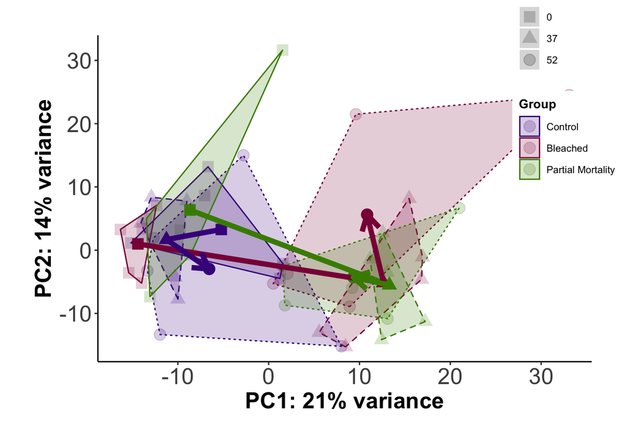

```r
gPCAdata <- plotPCA(gvst, intgroup = c("Group", "Day"), returnData=TRUE)
percentVar <- round(100*attr(gPCAdata, "percentVar")) #plot PCA of samples with all data

pca.centroids<- gPCAdata%>%
  dplyr::select(Day, Group, PC1, PC2)%>%
  dplyr::group_by(Day, Group)%>%
  dplyr::summarise(PC1.mean = mean(PC1),
                   PC2.mean = mean(PC2))

gPCAdata$Day.Group <- paste(gPCAdata$Day, gPCAdata$Group)
find_hull <- function(gPCAdata) gPCAdata[chull(gPCAdata$PC1, gPCAdata$PC2), ]
hulls <- plyr::ddply(gPCAdata, "Day.Group", find_hull)

PCA<-ggplot(gPCAdata, aes(PC1, PC2, color=Group)) +
  geom_point(size = 4, alpha=0.2, aes(shape = Day))+
  scale_colour_manual(values=c("#46008B", "#8B0046", "#468B00")) +
  scale_fill_manual(values=c("#46008B", "#8B0046", "#468B00")) +
  scale_shape_manual(values=c(15, 17, 19)) +
  theme_classic()+
#  ylim(-7,12)+
#  xlim(-6,6)+
  xlab(paste0("PC1: ",percentVar[1],"% variance")) +
  ylab(paste0("PC2: ",percentVar[2],"% variance")) +
#  geom_text(x=4.5, y=-4.75, label=paste("p(Day)=", z_pca$`Pr(>F)`[1]), size=4, color=ifelse(z_pca$`Pr(>F)`[1] < 0.05, "black", "darkgray")) +
#  geom_text(x=4.5, y=-5.5, label=paste("p(Group)=", z_pca$`Pr(>F)`[2]), size=4, color=ifelse(z_pca$`Pr(>F)`[2] < 0.05, "black", "darkgray")) +
#  geom_text(x=4.5, y=-6.25, label=paste("p(Day x Group)=", z_pca$`Pr(>F)`[3]), size=4, color=ifelse(z_pca$`Pr(>F)`[3] < 0.05, "black", "darkgray")) +
  theme(legend.text = element_text(size=8),
        legend.position="none",
        plot.background = element_blank(),
        legend.title = element_text(size=10),
        plot.margin = margin(1, 1, 1, 1, "cm"),
        axis.text = element_text(size=18),
        title = element_text(size=25, face="bold"),
        axis.title = element_text(size=18))

#Add centroids

#2. add centroids
PCAcen<-PCA +  geom_polygon(data = hulls, alpha = 0.2, aes(color = Group, fill = Group, lty = Day)) +
  geom_point(aes(x=PC1.mean, y=PC2.mean,color=Group, shape = Day), data=pca.centroids, size=4, show.legend=FALSE) +
  scale_linetype_manual(values = c("solid", "dashed", "dotted")) +
  scale_colour_manual(values=c("#46008B", "#8B0046", "#468B00"), breaks = c("Control","Bleached", "Partial-Mortality"), labels = c("Control", "Bleached", "Partial Mortality")) +
  scale_fill_manual(values=c("#46008B", "#8B0046", "#468B00"), breaks = c("Control","Bleached", "Partial-Mortality"), labels = c("Control", "Bleached", "Partial Mortality")) +
  scale_shape_manual(values=c(15, 17, 19)) +
  theme(legend.text = element_text(size=8),
        legend.position=c(0.95,0.85),
        plot.background = element_blank(),
        legend.title = element_text(size=10),
        plot.margin = margin(1, 1, 1, 1, "cm"),
        axis.text = element_text(size=18),
        title = element_text(size=25, face="bold"),
        axis.title = element_text(size=18))

#Add segments

#3. add segments
segpoints<-pca.centroids%>%
  gather(variable, value, -(Day:Group)) %>%
  unite(temp, Day, variable) %>%
  spread(temp, value)

names(segpoints)[2] <- "Day0_PC1.mean"
names(segpoints)[3] <- "Day0_PC2.mean"
names(segpoints)[4] <- "Day37_PC1.mean"
names(segpoints)[5] <- "Day37_PC2.mean"
names(segpoints)[6] <- "Day52_PC1.mean"
names(segpoints)[7] <- "Day52_PC2.mean"

PCAfull<-PCAcen +
  geom_segment(aes(x = Day0_PC1.mean, y = Day0_PC2.mean, xend = Day37_PC1.mean, yend = Day37_PC2.mean, colour = Group), data = segpoints, size=2, show.legend=FALSE) +
  geom_segment(aes(x = Day37_PC1.mean, y = Day37_PC2.mean, xend = Day52_PC1.mean, yend = Day52_PC2.mean, colour = Group), data = segpoints, size=2, arrow = arrow(length=unit(0.5,"cm")), show.legend=FALSE); PCAfull
```

```r
#ggsave(filename="output/TagSeq/Full_PCA_TagSeq.pdf", plot=PCAfull, dpi=300, width=12, height=10, units="in")
```